# Machine Learning

Basel R Bootcamp July 2018 [www.therbootcamp.com](https://therbootcamp.github.io) [@therbootcamp](https://twitter.com/therbootcamp)

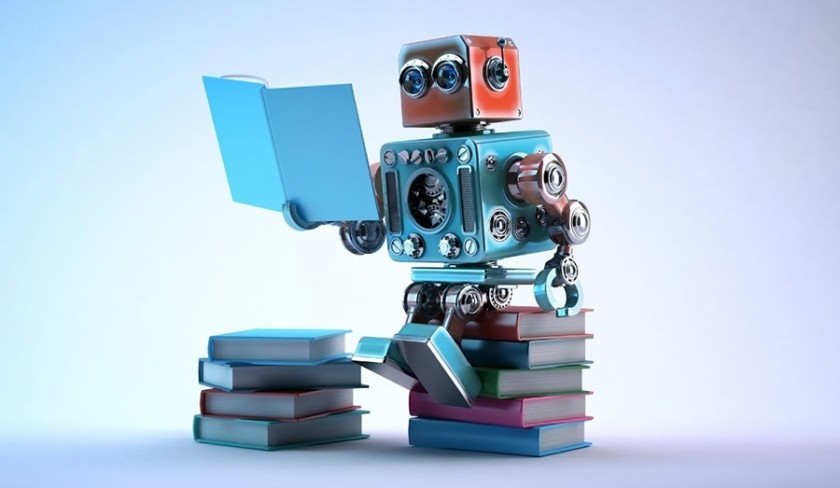

Source: Android Authority

### Overview

In this practical you’ll practice the basics of machine learning in R

By the end of this practical you will know how to:

1. Fit regression, decision trees, and random forests to training data using the original model packages
2. Explore each object with generic functions.
3. Predict outcomes from new data with all models.
4. Evaluate the model’s fitting and prediction performance.

### Packages

| Package | Installation |
| --- | --- |
| `tidyverse` | `install.packages("tidyverse")` |
| `broom` | `install.packages("broom")` |
| `rpart` | `install.packages("rpart")` |
| `FFTrees` | `install.packages("FFTrees")` |
| `partykit` | `install.packages("partykit")` |
| `party` | `install.packages("party")` |
| `randomForest` | `install.packages("randomForest")` |
| `caret` | `install.packages("caret")` |

### Datasets

```r
library(tidyverse)
library(rpart)
library(FFTrees)
library(partykit)
library(party)
library(randomForest)
library(rminer)
library(caret)


attrition_train <- read_csv("https://raw.githubusercontent.com/therbootcamp/therbootcamp.github.io/master/_sessions/_data/attrition_train.csv")
attrition_test <- read_csv("https://raw.githubusercontent.com/therbootcamp/therbootcamp.github.io/master/_sessions/_data/attrition_test.csv")
heartdisease_train <- read_csv("https://raw.githubusercontent.com/therbootcamp/therbootcamp.github.io/master/_sessions/_data/heartdisease_train.csv")
heartdisease_test <- read_csv("https://raw.githubusercontent.com/therbootcamp/therbootcamp.github.io/master/_sessions/_data/heartdisease_test.csv")
house_train <- read_csv("https://raw.githubusercontent.com/therbootcamp/therbootcamp.github.io/master/_sessions/_data/house_train.csv")
house_test <- read_csv("https://raw.githubusercontent.com/therbootcamp/therbootcamp.github.io/master/_sessions/_data/house_test.csv")
```

| File | Rows | Columns |
| --- | --- | --- |
| house_train.csv | 1000 | 21 |
| house_test.csv | 15000 | 21 |

### Glossary

| Function | Package | Description |
| --- | --- | --- |
| `summary()` | `base` | Get summary information from an R object |
| `names()` | `base` | See the named elements of a list |
| `LIST$NAME()` | `base` | Get the named element `NAME` from a list `OBJECT` |
| `predict(object, newdata)` | `base` | Predict the criterion values of `newdata` based on `object` |

### Examples

```r
# Machine learning basics ------------------------------------

# Step 0: Load packages-----------

library(tidyverse)    # Load tidyverse for dplyr and tidyr
library(rpart)        # For rpart()
library(broom)        # For tidy()
library(caret)        # For resamp
library(partykit)     # For nice decision trees

# Step 1: Load Training and Test data ----------------------

house_train <- read_csv("https://raw.githubusercontent.com/therbootcamp/therbootcamp.github.io/master/_sessions/_data/house_train.csv")

house_test <- read_csv("https://raw.githubusercontent.com/therbootcamp/therbootcamp.github.io/master/_sessions/_data/house_test.csv")

# Step 2: Explore training data -----------------------------

summary(house_train)

# We will do a log-transformation on price
#  because it is so heavily skewed

# Log-transform price
house_train <- house_train %>%
  mutate(price = log(price))

# Log-transform price
house_test <- house_test %>%
  mutate(price = log(price))

# Step 3: Fit models predicting price ------------------

# Regression
price_lm <- glm(formula = price ~ bedrooms + bathrooms + floors,
                data = house_train)

# Decision Trees
price_rpart <- rpart(formula = price ~ bedrooms + bathrooms + floors,
                     data = house_train)

# Step 4: Explore models -------------------------------

# Regression
summary(price_lm)

# Decision Trees
price_rpart
plot(price_rpart)
text(price_rpart)

# Nicer version!
plot(as.party(price_rpart))


# Step 5: Assess fitting accuracy ----------------------------


# Get fitted values
lm_fit <- predict(price_lm,
                 newdata = house_train)

rpart_fit <- predict(price_rpart,
                    newdata = house_train)

# Regression Fitting Accuracy
postResample(pred = lm_fit,
             obs = house_train$price)

# Decision Tree Fitting Accuracy
postResample(pred = rpart_fit,
             obs = house_train$price)

# Step 6: Predict new data -------------------------

lm_pred <- predict(object = price_lm,
                   newdata = house_test)

rpart_pred <- predict(object = price_rpart,
                      newdata = house_test)

# Step 7: Compare accuracy --------------------------

# Regression Prediction Accuracy
postResample(pred = lm_pred,
             obs = house_test$price)

# Decision Tree Prediction Accuracy
postResample(pred = rpart_pred,
             obs = house_test$price)


# Plot results

# Tidy competition results
competition_results <- tibble(truth = house_test$price,
                              Regression = lm_pred,
                              Decision_Trees = rpart_pred) %>%
                       gather(group, prediction, -truth)

# Plot!
ggplot(data = competition_results,
       aes(x = truth, y = prediction, col = group)) +
  geom_point(alpha = .2) +
  geom_abline(slope = 1, intercept = 0) +
  labs(title = "Predicting housing prices",
       subtitle = "Regression versus decision trees")
```

# Tasks

## A - Setup

1. Open your `baselrbootcamp` R project. It should already have the folders `1_Data` and `2_Code`. Make sure that the data files listed in the `Datasets` section above are in your `1_Data` folder

```r
# Done!
```

2. Open a new R script. At the top of the script, using comments, write your name and the date. Save it as a new file called `machinelearning_practical.R` in the `2_Code` folder.
3. Using `library()` load the set of packages for this practical listed in the packages section above.

```r
## NAME
## DATE
## Wrangling Practical

library(XX)
library(XX)
#...
```

4. For this practical, we’ll use two datasets related to the prices of houses in King County Washington. There is a *training* dataset `house_train.csv` and a model *testing* dataset `house_test.csv` data. Using the following template, load the datasets into R as `house_train` and `house_test`:

```r
house_train <- read_csv(file = "XXX/XXX")
```

5. Take a look at the first few rows of each dataset by printing them to the console.

## B - Walking through the 7 steps

```r
# Step 0: Load packages-----------

library(tidyverse)    # Load tidyverse for dplyr and tidyr
library(rpart)        # For rpart()
library(broom)        # For tidy()
library(caret)        # For resamp
library(partykit)     # For nice decision trees

# Step 1: Load Training and Test data ----------------------

house_train <- read_csv("https://raw.githubusercontent.com/therbootcamp/therbootcamp.github.io/master/_sessions/_data/house_train.csv")
house_test <- read_csv("https://raw.githubusercontent.com/therbootcamp/therbootcamp.github.io/master/_sessions/_data/house_test.csv")
# Step 2: Explore training data -----------------------------

summary(house_train)
```

```
      id                 date                         price
 Length:1000        Min.   :2014-05-02 00:00:00   Min.   :  82000
 Class :character   1st Qu.:2014-07-24 00:00:00   1st Qu.: 324875
 Mode  :character   Median :2014-10-13 12:00:00   Median : 452750
                    Mean   :2014-10-27 04:07:40   Mean   : 549251
                    3rd Qu.:2015-02-10 00:00:00   3rd Qu.: 636900
                    Max.   :2015-05-14 00:00:00   Max.   :5110800
    bedrooms      bathrooms     sqft_living      sqft_lot
 Min.   :1.00   Min.   :0.75   Min.   : 520   Min.   :   740
 1st Qu.:3.00   1st Qu.:1.75   1st Qu.:1440   1st Qu.:  5200
 Median :3.00   Median :2.25   Median :1955   Median :  7782
 Mean   :3.41   Mean   :2.17   Mean   :2100   Mean   : 15011
 3rd Qu.:4.00   3rd Qu.:2.50   3rd Qu.:2540   3rd Qu.: 10779
 Max.   :7.00   Max.   :6.00   Max.   :8010   Max.   :920423
     floors      waterfront         view        condition
 Min.   :1.0   Min.   :0.000   Min.   :0.00   Min.   :1.00
 1st Qu.:1.0   1st Qu.:0.000   1st Qu.:0.00   1st Qu.:3.00
 Median :1.5   Median :0.000   Median :0.00   Median :3.00
 Mean   :1.5   Mean   :0.008   Mean   :0.24   Mean   :3.45
 3rd Qu.:2.0   3rd Qu.:0.000   3rd Qu.:0.00   3rd Qu.:4.00
 Max.   :3.0   Max.   :1.000   Max.   :4.00   Max.   :5.00
     grade         sqft_above   sqft_basement     yr_built
 Min.   : 4.00   Min.   : 520   Min.   :   0   Min.   :1900
 1st Qu.: 7.00   1st Qu.:1220   1st Qu.:   0   1st Qu.:1954
 Median : 7.00   Median :1610   Median :   0   Median :1977
 Mean   : 7.68   Mean   :1813   Mean   : 288   Mean   :1972
 3rd Qu.: 8.00   3rd Qu.:2200   3rd Qu.: 550   3rd Qu.:1996
 Max.   :12.00   Max.   :6430   Max.   :3500   Max.   :2015
  yr_renovated     zipcode           lat            long
 Min.   :   0   Min.   :98001   Min.   :47.2   Min.   :-122
 1st Qu.:   0   1st Qu.:98033   1st Qu.:47.5   1st Qu.:-122
 Median :   0   Median :98059   Median :47.6   Median :-122
 Mean   :  66   Mean   :98076   Mean   :47.6   Mean   :-122
 3rd Qu.:   0   3rd Qu.:98117   3rd Qu.:47.7   3rd Qu.:-122
 Max.   :2015   Max.   :98199   Max.   :47.8   Max.   :-121
 sqft_living15    sqft_lot15
 Min.   : 620   Min.   :   915
 1st Qu.:1500   1st Qu.:  5200
 Median :1820   Median :  7830
 Mean   :1989   Mean   : 13190
 3rd Qu.:2370   3rd Qu.: 10142
 Max.   :5030   Max.   :411962
```

```r
# We will do a log-transformation on price
#  because it is so heavily skewed

# Log-transform price
house_train <- house_train %>%
  mutate(price = log(price))

# Log-transform price
house_test <- house_test %>%
  mutate(price = log(price))

# Step 3: Fit models predicting price ------------------

# Regression
price_lm <- glm(formula = price ~ bedrooms + bathrooms + floors,
                data = house_train)

# Decision Trees
price_rpart <- rpart(formula = price ~ bedrooms + bathrooms + floors,
                     data = house_train)

# Step 4: Explore models -------------------------------

# Regression
summary(price_lm)
```

```
Call:
glm(formula = price ~ bedrooms + bathrooms + floors, data = house_train)

Deviance Residuals:
   Min      1Q  Median      3Q     Max
-1.312  -0.326  -0.002   0.298   1.945

Coefficients:
            Estimate Std. Error t value Pr(>|t|)
(Intercept)  12.1723     0.0622   195.6   <2e-16 ***
bedrooms      0.0373     0.0187     2.0    0.046 *
bathrooms     0.3661     0.0234    15.6   <2e-16 ***
floors       -0.0239     0.0299    -0.8    0.425
---
Signif. codes:  0 '***' 0.001 '**' 0.01 '*' 0.05 '.' 0.1 ' ' 1

(Dispersion parameter for gaussian family taken to be 0.191)

    Null deviance: 277.59  on 999  degrees of freedom
Residual deviance: 190.42  on 996  degrees of freedom
AIC: 1189

Number of Fisher Scoring iterations: 2
```

```r
# Decision Trees
price_rpart
```

```
n= 1000

node), split, n, deviance, yval
      * denotes terminal node

 1) root 1000 278.00 13.1
   2) bathrooms< 3.12 904 192.00 13.0
     4) bathrooms< 1.62 216  40.90 12.7 *
     5) bathrooms>=1.62 688 126.00 13.1
      10) bathrooms< 2.62 598  99.10 13.0 *
      11) bathrooms>=2.62 90  23.20 13.3 *
   3) bathrooms>=3.12 96  35.40 13.7
     6) bathrooms< 4.62 89  25.40 13.7
      12) bedrooms< 3.5 17   3.42 13.3 *
      13) bedrooms>=3.5 72  18.50 13.8 *
     7) bathrooms>=4.62 7   1.52 14.8 *
```

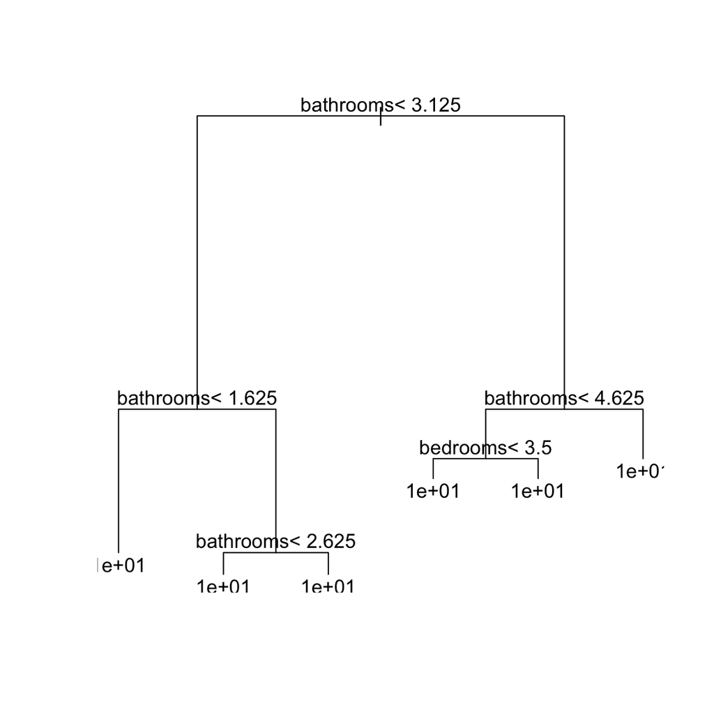

```r
plot(price_rpart)
text(price_rpart)
```

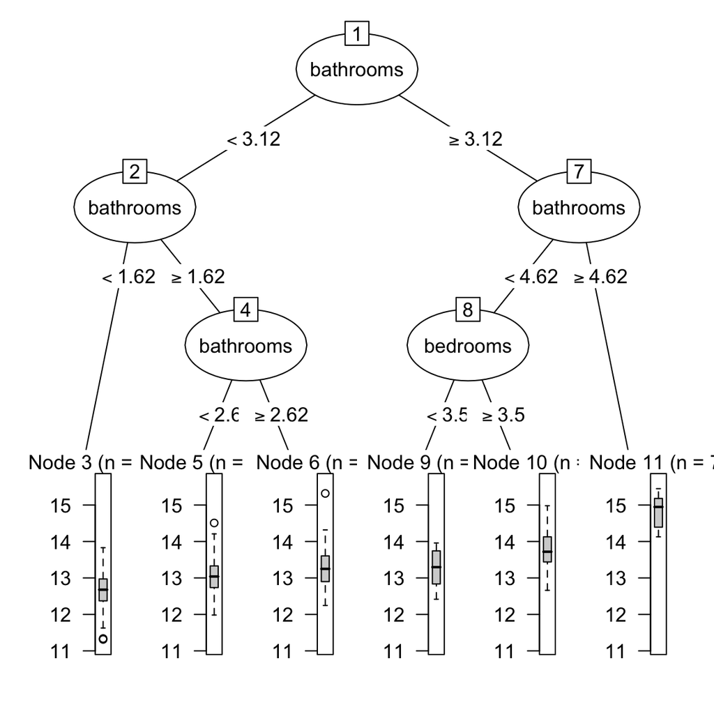

```r
# Nicer version!
plot(as.party(price_rpart))
```

```r
# Step 5: Assess fitting accuracy ----------------------------


# Get fitted values
lm_fit <- predict(price_lm,
                 newdata = house_train)

rpart_fit <- predict(price_rpart,
                    newdata = house_train)

# Regression Fitting Accuracy
postResample(pred = lm_fit,
             obs = house_train$price)
```

```
    RMSE Rsquared      MAE
   0.436    0.314    0.351
```

```r
# Decision Tree Fitting Accuracy
postResample(pred = rpart_fit,
             obs = house_train$price)
```

```
    RMSE Rsquared      MAE
   0.432    0.328    0.346
```

```r
# Step 6: Predict new data -------------------------

lm_pred <- predict(object = price_lm,
                   newdata = house_test)

rpart_pred <- predict(object = price_rpart,
                      newdata = house_test)

# Step 7: Compare accuracy --------------------------

# Regression Prediction Accuracy
postResample(pred = lm_pred,
             obs = house_test$price)
```

```
    RMSE Rsquared      MAE
   0.438    0.308    0.352
```

```r
# Decision Tree Prediction Accuracy
postResample(pred = rpart_pred,
             obs = house_test$price)
```

```
    RMSE Rsquared      MAE
   0.444    0.289    0.354
```

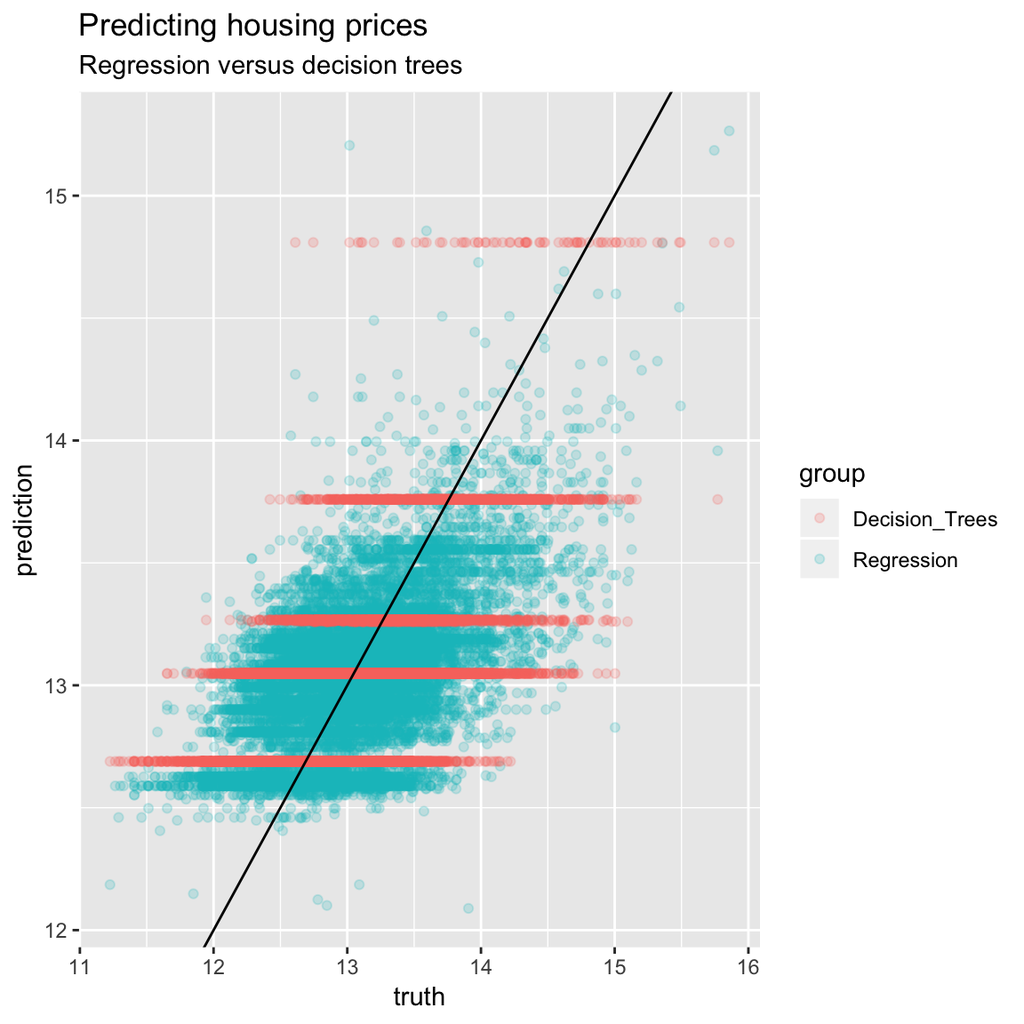

```r
# Plot results

# Tidy competition results
competition_results <- tibble(truth = house_test$price,
                              Regression = lm_pred,
                              Decision_Trees = rpart_pred) %>%
                       gather(group, prediction, -truth)

# Plot!
ggplot(data = competition_results,
       aes(x = truth, y = prediction, col = group)) +
  geom_point(alpha = .2) +
  geom_abline(slope = 1, intercept = 0) +
  labs(title = "Predicting housing prices",
       subtitle = "Regression versus decision trees")
```

1. Run Steps 0 through 4 in the Examples section above. Run each line of code individually and explore each object you create. Try to understand each of the steps! If you have trouble, ask for help!
2. Which of the three features (bedrooms, bathrooms, floors) do the regression and decision tree models use? Do they treat the features equally?
3. Run step 5. Look at the results. Which model has the best fitting performance?
4. Run Steps 6-7. Look at the results. Which model has the best prediction performance? How does each model’s prediction performance compare to its fitting performance?

## D - Include random forests

1. Random forests are much more complex than regression and decision trees. Try including Random forests in your analyses as a new competitor. You can use the `randomForest()` function from the `randomForest` package to fit your model!

```r
# Just add the following:

# Regression
price_rf <- randomForest(formula = price ~ bedrooms + bathrooms + floors,
                         data = house_train)


# Get fitted values
rf_fit <- predict(price_rf,
                 newdata = house_train)


# prediction acuracy
postResample(pred = rf_fit,
             obs = house_train$price)
```

```
    RMSE Rsquared      MAE
   0.415    0.395    0.335
```

```r
# Get fitted values
rf_pred <- predict(price_rf,
                 newdata = house_test)


# prediction acuracy
postResample(pred = rf_pred,
             obs = house_test$price)
```

```
    RMSE Rsquared      MAE
   0.435    0.326    0.347
```

2. How does the *fitting* performance of random forests compare to the other algorithms in training?

```r
# rf is better!
```

3. How does the *prediction* performance of random forests compare to the other algorithms in testing?

```r
# rf is better!
```

## E - Include more features

Until now, you’ve only been predicting price based on 3 features (bedrooms, bathrooms, and floors). Of course, you have access to lots more data to predict housing prices! Now it’s time to try using more data to predict price.

1. Look closely again at the columns in the `house_train` data. There are two features in the data that you definitely *don’t* want to include in your models. Which two are they?
2. Remove those two features from your training data using the following template:

```r
# Remove two features (columns) from house_train
house_train <- house_train %>%
  select(-XX, -XX)
```

```r
# Remove two features (columns) from house_train
house_train <- house_train %>%
  select(-id, -date)
```

3. Re-run your models, but now predict price based on *all* of the features. To do this, use the formula short hand `formula = price ~ .`.

```r
# Regression example
price_lm <- glm(formula = price ~.,
                data = house_train)

# Same with other models...
```

4. How does the overall fitting and prediction performance of the models compare to when you only used three features? Did each model improve?

```r
# Yes each model improves!!
```

## F - Predict the year a house was built

```r
# On your own!
```

So far, we have predicted house prices based on many features. Now, see how well you can predict the *year* a house was built (`yr_built`) based on the following four features: bedrooms, bathrooms, condition, sqft_living.

1. Go through Steps 0 through 4 using regression `glm()` and decision trees `rpart()` to build models predicting the year a house was built `yr_built` based on `bedrooms`, `bathrooms`, `condition`, `sqft_living`.
2. Based on your model exploration (Step 4), which of the four features seem to be the most important in predicting the year a house was built?
3. Complete Steps 5 through 7.
4. Which of your three models is the best at predicting the year a house was built?

# Additional reading

- For more details check out `caret`’s vignette using `vignette("caret")`.
- Also check out [Applied Predictive Modeling](https://www.amazon.com/dp/B005Z29QT4/ref=cm_sw_su_dp) Kuhn & Johnson.